# task 1. linear_regression

### Author : Mrudula Mende

## Task 1 : Prediction using Supervised Machine Learning

## GRIP @ The Sparks Foundation

In this regression task I tried to predict the percentage of marks that a student is expected to score based upon the number of hours they studied.

This is a simple linear regression task as it involves just two variables.

```python
#Importing  the required libraries
from sklearn.model_selection import train_test_split
from sklearn.linear_model import LinearRegression
import matplotlib.pyplot as plt
import pandas as pd
import numpy as np
```

## Step 1 - Reading the data from source

```python
# Reading data from remote link
url = "https://raw.githubusercontent.com/AdiPersonalWorks/Random/master/student_scores%20-%20student_scores.csv"
s_data = pd.read_csv(url)
print("Data import successful")

s_data.head(10)
```

```
Data import successful
```

|  | Hours | Scores |
| --- | --- | --- |
| 0 | 2.5 | 21 |
| 1 | 5.1 | 47 |
| 2 | 3.2 | 27 |
| 3 | 8.5 | 75 |
| 4 | 3.5 | 30 |
| 5 | 1.5 | 20 |
| 6 | 9.2 | 88 |
| 7 | 5.5 | 60 |
| 8 | 8.3 | 81 |
| 9 | 2.7 | 25 |

## Step 2 - Input Data Visualization

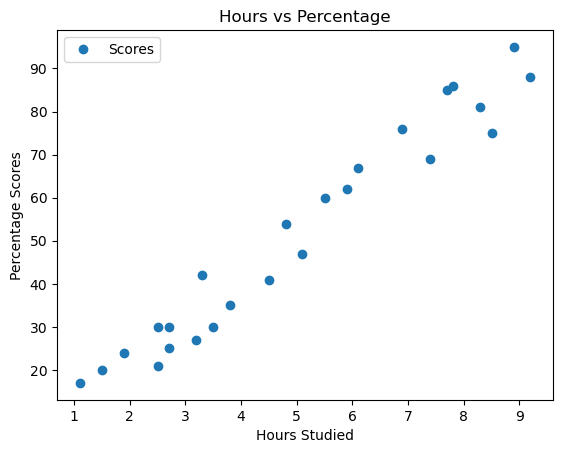

```python
#plotting the distributions of scores
s_data.plot(x= 'Hours', y='Scores', style= 'o')
plt.title('Hours vs Percentage')
plt.xlabel('Hours Studied')
plt.ylabel('Percentage Scores')
plt.show()
```

From the graph we can clearly assume a positive linear relation between the number of hours studied and percentage of score.

## Step 3 - Data Preprocessing

This step involved divison of data into "attributes" (inputs) and "labels" (outputs).

```python
x = s_data.iloc[:,:-1].values
y = s_data.iloc[:,1].values
```

## Step 4 - Model Training

splitting the data into training and testing sets and training the algorithm

```python
x_train, x_test, y_train, y_test= train_test_split(x,y,test_size = 0.2, random_state = 0)
regressor = LinearRegression()
regressor.fit(x_train.reshape(-1,1), y_train)

print("Training Complete.")
```

```
Training Complete.
```

## Step 5 - Plotting the Line of regression

Since our model is trained now, it's the time to visualize the best-fit line of regression.

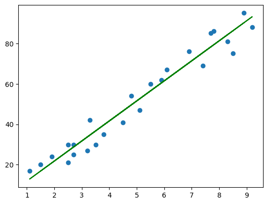

```python
#plotting the regression line
line = regressor.coef_*x+regressor.intercept_

#plotting for the test data
plt.scatter(x,y)
plt.plot(x, line,color='green');
plt.show()
```

## Step 6 - Making Predictions

Now that we have trained our algorithm it's time to test the model by making some predictions. For this we will use our test-set data.

```python
#Testing data- In Hours
print(x_test)
#Predicting the scores
y_pred = regressor.predict(x_test)
```

```
[[1.5]
 [3.2]
 [7.4]
 [2.5]
 [5.9]]
```

## Step 7 - Comparing Actual vs Predicted

```python
#comparing Actual vs Predicted
df = pd.DataFrame ({'Actual': y_test, 'Predicted': y_pred})
df
```

|  | Actual | Predicted |
| --- | --- | --- |
| 0 | 20 | 16.884145 |
| 1 | 27 | 33.732261 |
| 2 | 69 | 75.357018 |
| 3 | 30 | 26.794801 |
| 4 | 62 | 60.491033 |

```python
#Estimatingtraining and test score
print("Training Score:",regressor.score(x_train,y_train))
print("Testing Score:",regressor.score(x_test,y_test))
```

```
Training Score: 0.9515510725211552
Testing Score: 0.9454906892105356
```

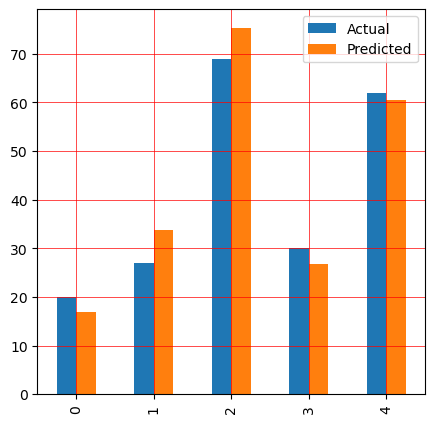

```python
#Plotting the bar graph to depict the difference between the actual and predicted value

df.plot(kind='bar',figsize=(5,5))
plt.grid(which='major', linewidth='0.5', color='red')
plt.grid(which='minor',linewidth='0.5', color='blue')
plt.show()
```

```python
# Testing the model with our own data
hours = 9.25
test = np.array([hours])
test = test.reshape(-1, 1)
own_pred = regressor.predict(test)
print("No of Hours = {}".format(hours))
print("Predicted Score = {}".format(own_pred[0]))
```

```
No of Hours = 9.25
Predicted Score = 93.69173248737538
```

## Step 8 - Evaluating the model

The final step is to evaluate the performance of algorithm. This step is particularly important to compare how well different algorithms perform on a particular dataset. Here different errors have been calculated to compare the model performance and predict the accuracy.

```python
from sklearn import metrics
print('Mean Absolute Error:',metrics.mean_absolute_error(y_test, y_pred))
print('Mean Squared Error:',metrics.mean_squared_error(y_test,y_pred))
print('Root Mean Squared Error:', np.sqrt(metrics.mean_squared_error(y_test,y_pred)))
print('R-2:', metrics.r2_score(y_test,y_pred))
```

```
Mean Absolute Error: 4.183859899002975
Mean Squared Error: 21.5987693072174
Root Mean Squared Error: 4.6474476121003665
R-2: 0.9454906892105356
```

# Conclusion

In this I was able to carry-out Prediction using Supervised ML task and was able to evaluate the models performance on various parameters.